# Presentation Slides Code

2024-10-28

# Introduction

# Slide Details

Before creating all figures, the code below will call the cleaned data that has gone through data preparation process. The detail of the data preparation process can be found in file **“01_Data_Preparation.Rmd”**.

```r
alldata_pres <- readRDS(here('results/all_data.rds'))
```

## Slide 6

In this slide, the descriptive statistics table was created using the code below. Additionally, this can be found in the **“02_Exploratory_Data_Analysis.Rmd”** specifically in the **“Descriptive Statistics”** section.

```r
# Populate descriptive stats table
desc_stats_flt_pres <- alldata_pres %>%
  group_by(Element_Symbol, Element_Description) %>%
  summarise(min = min(Element_Value_ppm),
         max = max(Element_Value_ppm),
         mean = mean(Element_Value_ppm),
         median = median(Element_Value_ppm),
         range = max(Element_Value_ppm) - min(Element_Value_ppm),
         q1 = quantile(Element_Value_ppm, 0.25),
         q3 = quantile(Element_Value_ppm, 0.75),
         iqr = IQR(Element_Value_ppm),
         sd = sd(Element_Value_ppm),
         var = var(Element_Value_ppm),
         skewness = moments::skewness(Element_Value_ppm),
         kurtosis = moments::kurtosis(Element_Value_ppm)) %>%
  filter(Element_Symbol %in% c("REE", "HREE", "LREE", "Ag", "Cd", "Co", "Cu", "Li", "Mo", "Ni", "Pb", "Sc", "Tl", "Zn")) %>%
  select(Element_Symbol, min, max, mean, median, sd, kurtosis)

print(desc_stats_flt_pres)
```

```
## # A tibble: 14 × 7
## # Groups:   Element_Symbol [14]
##    Element_Symbol   min    max    mean  median     sd kurtosis
##    <chr>          <dbl>  <dbl>   <dbl>   <dbl>  <dbl>    <dbl>
##  1 Ag              0.1    0.66   0.207   0.18   0.119     5.78
##  2 Cd              0.01   0.72   0.125   0.09   0.109     9.84
##  3 Co              2    134     15.4    10     19.3      17.7
##  4 Cu              1    255     42.0    47     29.0      13.1
##  5 HREE            1.1   30.6    8.67    8.2    4.81      6.71
##  6 LREE           11.7  554.   134.    140.    71.1       6.99
##  7 Li              5    285     47.7    40     39.5       9.53
##  8 Mo              0.1   20.6    4.46    4      3.29     10.2
##  9 Ni              1    360     17.0     7     38.3      44.1
## 10 Pb              0.89  83.4   21.7    21     14.5       6.14
## 11 REE            19.6  611    159.    165.    78.9       6.57
## 12 Sc              2.2   67.8   15.5    16.2    8.30      8.48
## 13 Tl              0.03  10      1.94    0.715  3.12      5.78
## 14 Zn              1    307     65.4    66     49.6       4.13
```

## Slide 7

This correlation matrix plot can be found in the **“02_Exploratory_Data_Analysis.Rmd”** specifically in the **“Correlation Matrix plot”** section. The code used to generate this plot is:

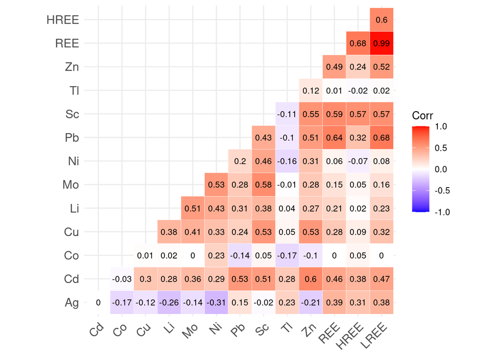

```r
res_cor_cop_pres <- alldata_pres %>%
  select(Project_Name,Sample_ID,Element_Symbol,PAAS_normalised_value) %>%
  pivot_wider(names_from = Element_Symbol,values_from = c(PAAS_normalised_value))


corr_cop_cheaper_pres <- cor(res_cor_cop_pres[,c("Ag", "Cd", "Co", "Cu", "Li", "Mo", "Ni", "Pb", "Sc", "Tl", "Zn", "REE", "HREE", "LREE")],
                        use="pairwise.complete.obs")

# corr_cop_cheaper <- data.frame(corr_cop[c("REE", "HREE", "LREE"), c("Ag", "Cd", "Co", "Cu", "Li", "Mo", "Ni", "Pb", "Sc", "Tl", "Zn")])

pg_cop_cheaper_pres <- ggcorrplot(corr_cop_cheaper_pres,
                     method = "square",
                     type = "lower",
                     outline.col = "white",
                     lab = TRUE,
                     lab_size = 3)

print(pg_cop_cheaper_pres)
```

## Slide 9 - Predictive Modelling…(4)

The result table was generated through a long modelling process which can be found in the **“03_Predictive_Analysis.Rmd”** file. The result table is generated by calling the object that has been saved in the file mentioned earlier to make this document tidy. Please refer to that document for more detailed information. The table below shows predictive model for predicting REE.

```r
results_ree_test_pres <- readRDS(here('Final_report/Final_report_files/results_ree_test_df.rds'))

print(results_ree_test_pres)
```

```
## # A tibble: 4 × 8
##   target_var method        model_scenarios   elements  RMSE   MAE  MAPE R_Square
##   <chr>      <chr>         <chr>             <chr>    <dbl> <dbl> <dbl>    <dbl>
## 1 REE        Random Forest Elements with co… Pb, Sc    55.6  38.0 0.294    0.479
## 2 REE        Random Forest Default tuned     All ele…  47.6  33.9 0.264    0.619
## 3 REE        Random Forest Elements with hi… Pb, Tl,…  48.8  35.8 0.278    0.599
## 4 REE        XGBoost       Default tuned     All ele…  50.4  37.3 0.288    0.573
```

## Slide 10 - Predictive Modelling…(5)

The result table was generated through a long modelling process which can be found in the **“03_Predictive_Analysis.Rmd”** file. The result table is generated by calling the object that has been saved in the file mentioned earlier to make this document tidy. Please refer to that document for more detailed information. The table below shows predictive model for predicting HREE.

```r
# Load hree test result
results_hree_test_pres <- readRDS(here('Final_report/Final_report_files/results_hree_test_df.rds'))

print(results_hree_test_pres)
```

```
## # A tibble: 3 × 8
##   target_var method        model_scenarios   elements  RMSE   MAE  MAPE R_Square
##   <chr>      <chr>         <chr>             <chr>    <dbl> <dbl> <dbl>    <dbl>
## 1 HREE       Random Forest Default tuned     All ele…  3.33  2.13 0.289    0.461
## 2 HREE       Random Forest Model with high … Pb, Sc    3.14  2.24 0.369    0.477
## 3 HREE       XGBoost       Model with high … Pb, Sc    3.38  2.45 0.374    0.394
```

## Slide 11 - Predictive Modelling…(6)

The result table was generated through a long modelling process which can be found in the **“03_Predictive_Analysis.Rmd”** file. The result table is generated by calling the object that has been saved in the file mentioned earlier to make this document tidy. Please refer to that document for more detailed information. The table below shows predictive model for predicting LREE.

```r
# Load lree test result
results_lree_test_pres <- readRDS(here('Final_report/Final_report_files/results_lree_test_df.rds'))

print(results_lree_test_pres)
```

```
## # A tibble: 4 × 8
##   target_var method        model_scenarios   elements  RMSE   MAE  MAPE R_Square
##   <chr>      <chr>         <chr>             <chr>    <dbl> <dbl> <dbl>    <dbl>
## 1 LREE       Random Forest Default tuned     All ele…  39.6  26.6 0.251    0.610
## 2 LREE       Random Forest Elements with hi… Tl, Pb,…  40.5  27.7 0.267    0.593
## 3 LREE       Random Forest Elements with co… Pb, Sc,…  38.4  29.6 0.314    0.633
## 4 LREE       XGBoost       Elements with co… Pb, Sc,…  41.7  31.1 0.274    0.568
```

## Slide 12

Similar to the last few slides, all these plots are the continuation of the process after the modelling part. All these codes were used in the **“03_Predictive_Analysis.Rmd”** file as well. Therefore, please refer to that document for a more detailed information.

### REE Plot

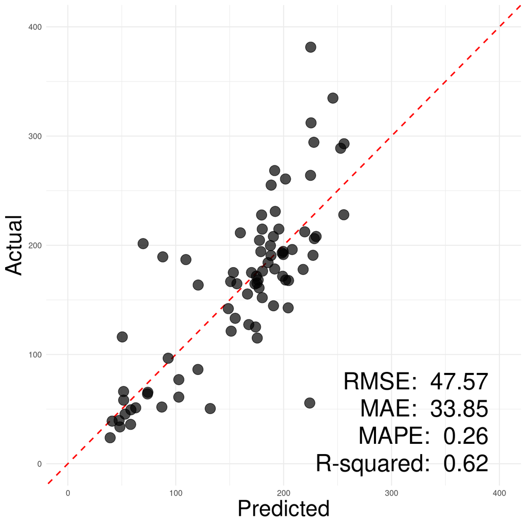

Actual vs Prediction Results

```r
# Plot for REE
ree_rmse_value_pres <- results_ree_test_pres[2,5]
ree_rsq_value_pres <- results_ree_test_pres[2,8]
ree_mae_value_pres <- results_ree_test_pres[2,6]
ree_mape_value_pres <- results_ree_test_pres[2,7]

# Load ree test result
ree_results_test <- readRDS(here('Final_report/Final_report_files/ree_results_test.rds'))

# Creating the plot
ree_results_test %>%
  filter(model %in% c("RF_Rdm_Tuned_3")) %>%
  ggplot(aes(.pred, truth)) +
  geom_abline(lty = 2, linewidth = 0.75, linetype = "dashed", colour='red') +
  geom_point(alpha = 0.7, colour = "black", size = 5) +
  xlim(c(0,400)) +
  ylim(c(0,400)) +
  xlab("Predicted") +
  ylab("Actual") +
  theme_minimal() +
  theme(axis.title.x = element_text(size = 24),            # Increase X-axis title size
        axis.title.y = element_text(size = 24)) +          # Increase Y-axis title size
  # Annotate the plot with the metrics
  annotate("text", x = 390, y = 76, label = paste("RMSE: ", round(ree_rmse_value_pres, 2)), size = 9, hjust = 1) +
  annotate("text", x = 390, y = 51, label = paste("MAE: ", round(ree_mae_value_pres, 2)), size = 9, hjust = 1) +
  annotate("text", x = 390, y = 26, label = paste("MAPE: ", round(ree_mape_value_pres, 2)), size = 9, hjust = 1) +
  annotate("text", x = 390, y = 1, label = paste("R-squared: ", round(ree_rsq_value_pres, 2)), size = 9, hjust = 1)
```

### HREE Plot

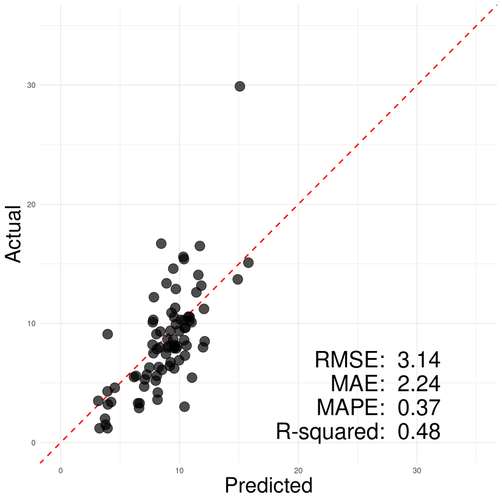

Actual vs Prediction Results

```r
# Getting metrics values
hree_rmse_value_pres <- results_hree_test_pres[2,5]
hree_rsq_value_pres <- results_hree_test_pres[2,8]
hree_mae_value_pres <- results_hree_test_pres[2,6]
hree_mape_value_pres <- results_hree_test_pres[2,7]

# Load hree test result
hree_results_test <- readRDS(here('Final_report/Final_report_files/hree_results_test.rds'))

hree_results_test %>%
  filter(model %in% c("RF_Rdm_Tuned_HREE_3")) %>%
  ggplot(aes(.pred, truth)) +
  geom_abline(lty = 2, linewidth = 0.75, linetype = "dashed", colour='red') +
  geom_point(alpha = 0.7, colour = "black", size = 5) +
  xlim(c(0,35)) +
  ylim(c(0,35)) +
  xlab("Predicted") +
  ylab("Actual") +
  # facet_wrap(~train) +
  theme_minimal() +
  theme(axis.title.x = element_text(size = 24),            # Increase X-axis title size
        axis.title.y = element_text(size = 24)) +          # Increase Y-axis title size
  # Annotate the plot with the metrics
  annotate("text", x = 32, y = 7, label = paste("RMSE: ", round(hree_rmse_value_pres, 2)), size = 9, hjust = 1) +
  annotate("text", x = 32, y = 5, label = paste("MAE: ", round(hree_mae_value_pres, 2)), size = 9, hjust = 1) +
  annotate("text", x = 32, y = 3, label = paste("MAPE: ", round(hree_mape_value_pres, 2)), size = 9, hjust = 1) +
  annotate("text", x = 32, y = 1, label = paste("R-squared: ", round(hree_rsq_value_pres, 2)), size = 9, hjust = 1)
```

### LREE Plot

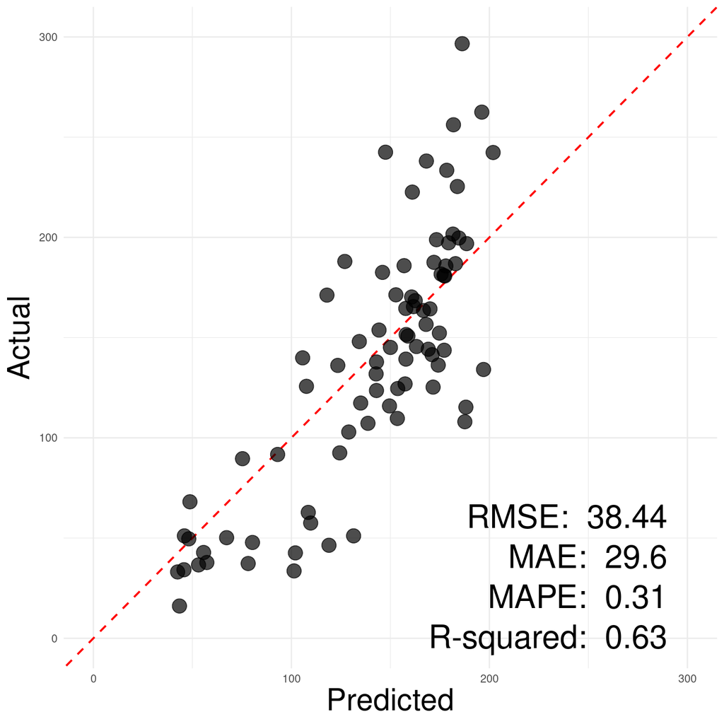

Actual vs Prediction Results

```r
# Getting metrics values
lree_rmse_value_pres <- results_lree_test_pres[3,5]
lree_rsq_value_pres <- results_lree_test_pres[3,8]
lree_mae_value_pres <- results_lree_test_pres[3,6]
lree_mape_value_pres <- results_lree_test_pres[3,7]

# Load lree test result
lree_results_test <- readRDS(here('Final_report/Final_report_files/lree_results_test.rds'))

# Generate the plt
lree_results_test %>%
  filter(model %in% c("RF_Rdm_Tuned_LREE_4")) %>%
  ggplot(aes(.pred, truth)) +
  geom_abline(lty = 2, linewidth = 0.75, linetype = "dashed", colour='red') +
  geom_point(alpha = 0.7, colour = "black", size = 5) +
  xlim(c(0,300)) +
  ylim(c(0,300)) +
  xlab("Predicted") +
  ylab("Actual") +
  theme_minimal() +
  theme(axis.title.x = element_text(size = 24),            # Increase X-axis title size
        axis.title.y = element_text(size = 24)) +          # Increase Y-axis title size
  # Annotate the plot with the metrics
  annotate("text", x = 290, y = 61, label = paste("RMSE: ", round(lree_rmse_value_pres, 2)), size = 9, hjust = 1) +
  annotate("text", x = 290, y = 41, label = paste("MAE: ", round(lree_mae_value_pres, 2)), size = 9, hjust = 1) +
  annotate("text", x = 290, y = 21, label = paste("MAPE: ", round(lree_mape_value_pres, 2)), size = 9, hjust = 1) +
  annotate("text", x = 290, y = 1, label = paste("R-squared: ", round(lree_rsq_value_pres, 2)), size = 9, hjust = 1)
```